# Analysis of Remote Entry Level Data Analyst Jobs Descriptions on Indeed.com

## by Yehia El-Balky

## Introduction

For this project, I wanted to analyze all current remote entry level Data Analyst jobs descriptions on Indeed.com (Data was extracted on 3-11-2021) in order to get a glimpse of the most frequent Data Analysis tools required in remote entry level jobs, which is probably the best & easiest choice for anyone interested in gaining some work experience in order to get into the vast field of Data Science.

After extraction & cleaning, we were left with 229 remote entry level Data Analyst jobs descriptions to work with.

## Word Cloud

The word cloud of Data Analysis tools in our extracted jobs descriptions.

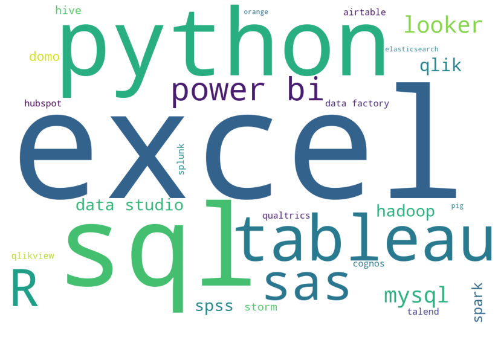

```python
# Plotting word cloud

import matplotlib.pyplot as plt
from wordcloud import WordCloud

wc = WordCloud(background_color="white", width=1200, height=800).generate_from_frequencies(tools_counts)
plt.figure(figsize=(15,10))
plt.axis('off')
plt.imshow(wc);
```

## Most Frequently Mentioned Tools

Excel seems to dominate remote entry level Data Analyst jobs with a mentioning rate of around 80%, followed up by SQL at ~60%, then Python at ~41%, Tableau at ~33%, both R & SAS at ~21%, Power BI at ~15%, then both MySQL & Looker at ~6%.

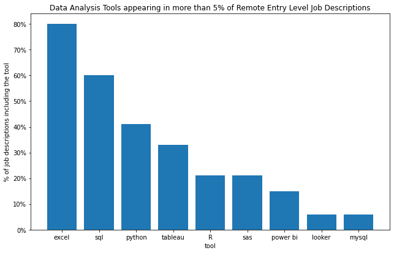

```python
# Plotting tools with frequency higher than 5%

import warnings
warnings.filterwarnings("ignore")

top_tools = {key: value for key, value in sorted_tools_percentages.items() if value > 0.05}

fig, ax = plt.subplots()
plt.bar(top_tools.keys(), top_tools.values())

plt.title('Data Analysis Tools appearing in more than 5% of Remote Entry Level Job Descriptions')
plt.xlabel('tool')
plt.ylabel('% of job descriptions including the tool')

fig.set_size_inches(10.5, 6.5)
ax.set_yticklabels(str(i) + '%' for i in range(0, 90, 10));
```

## No. of Tools per Job Description

Most remote entry level Data Analyst jobs mentioned 3 tools in their descriptions, with the least ones mentioning only one tool, and the highest ones mentioning ten.

```
Median of no. of tools per job description = 3
```

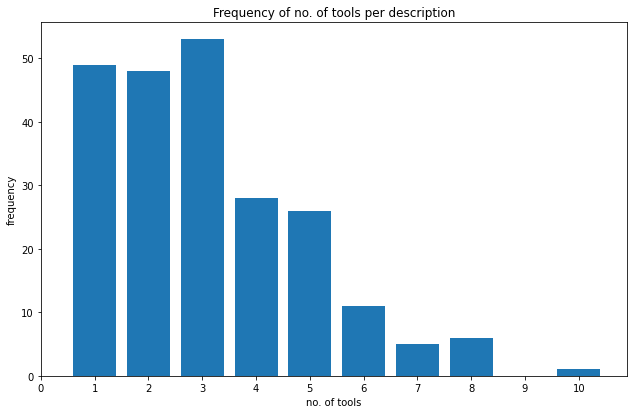

```python
# No. of tools per description

from collections import Counter

tools_per_description_frequencies = Counter(tools_per_description.values())

print('Median of no. of tools per job description = ' + str(median(tools_per_description.values())))

fig, ax = plt.subplots()
plt.bar(tools_per_description_frequencies.keys(), tools_per_description_frequencies.values())

plt.title('Frequency of no. of tools per description')
plt.xlabel('no. of tools')
plt.ylabel('frequency')

fig.set_size_inches(10.5, 6.5)
ax.set_xticks(range(0, 11));
```

## Tool: Percentage of Jobs Desriptions Mentioning only that Tool

Seems like having Excel only in your tool box may qualify you for about 15% of remote entry level Data Analyst jobs!

```python
# Checking the percentages of jobs descriptions completely covered by each tool

# List of jobs descriptions mentioning one tool only
one_tool_descriptions = [desription for desription in jobs_descriptions if tools_per_description[desription] == 1]

# Creating a dictionary of tools counts in one-tool jobs descriptions
tools_1_counts = initialize_count_dictionary()
tools_1_counts = fill_count_dictionary(tools_1_counts, one_tool_descriptions)
sorted_tools_1_counts = sorted_dictionary(tools_1_counts)

sorted_tools_1_percentages = get_tool_percentages(sorted_tools_1_counts)
sorted_tools_1_percentages
```

```
{'excel': 0.15,
 'sql': 0.03,
 'python': 0.02,
 'sas': 0.01,
 'tableau': 0.0,
 'airtable': 0.0,
 'spark': 0.0,
 'hadoop': 0.0,
 'storm': 0.0,
 'qlikview': 0.0,
 'splunk': 0.0,
 'power bi': 0.0,
 'data studio': 0.0,
 'cognos': 0.0,
 'looker': 0.0,
 'qlik': 0.0,
 'domo': 0.0,
 'mysql': 0.0,
 'spss': 0.0,
 'talend': 0.0,
 'hubspot': 0.0,
 'orange': 0.0,
 'qualtrics': 0.0,
 'elasticsearch': 0.0,
 'hive': 0.0,
 'data factory': 0.0,
 'pig': 0.0,
 'R': 0.0}
```

```python
def plot_top_tools(tools_tuples_percentages, size):
    '''Function for plotting tuples of tools appearing in more than 5% of the job descriptions'''

    top_tools_tuples = {key: value for key, value in tools_tuples_percentages.items() if value > 0.05}

    fig, ax = plt.subplots()
    plt.barh([' & '.join(set) for set in top_tools_tuples.keys()], top_tools_tuples.values())

    plt.title(size.capitalize() + 's of Data Analysis Tools appearing in more than 5% of Remote Entry Level Job Descriptions')
    plt.xlabel('% of job descriptions including the ' + size)
    plt.ylabel('tools ' + size)

    fig.set_size_inches(10.5, 6.5)
    x_range = range(0, int(max(list(top_tools_tuples.values()))*100)+10, 10)
    ax.set_xticks([i/100 for i in x_range])
    ax.set_xticklabels(str(i) + '%' for i in range(0, int(max(list(top_tools_tuples.values()))*100)+10, 10));
```

## Most Frequently Mentioned Pairs of Tools

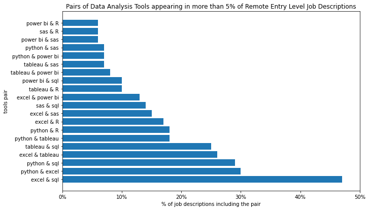

```python
def plot_top_tools(tools_tuples_percentages, size):
    '''Function for plotting tuples of tools appearing in more than 5% of the job descriptions'''

    top_tools_tuples = {key: value for key, value in tools_tuples_percentages.items() if value > 0.05}

    fig, ax = plt.subplots()
    plt.barh([' & '.join(set) for set in top_tools_tuples.keys()], top_tools_tuples.values())

    plt.title(size.capitalize() + 's of Data Analysis Tools appearing in more than 5% of Remote Entry Level Job Descriptions')
    plt.xlabel('% of job descriptions including the ' + size)
    plt.ylabel('tools ' + size)

    fig.set_size_inches(10.5, 6.5)
    x_range = range(0, int(max(list(top_tools_tuples.values()))*100)+10, 10)
    ax.set_xticks([i/100 for i in x_range])
    ax.set_xticklabels(str(i) + '%' for i in range(0, int(max(list(top_tools_tuples.values()))*100)+10, 10));

plot_top_tools(sorted_tools_double_percentages, 'pair')
```

## Pair of Tools: Percentage of Jobs Desriptions Mentioning both Tools only or only one of them

Seems like having Excel & SQL in your tool box may qualify you for about 28% of remote entry level Data Analyst jobs, while having Excel & SAS or Python for about 19%.

> Learning SQL given you are proficient in Excel may increase the range of jobs you're qualified for by ~13%.

```python
# Checking the percentages of jobs descriptions completely covered by each tools pair

two_tools_descriptions = [desription for desription in jobs_descriptions if tools_per_description[desription] == 2]

tools_2_counts = {}

# Initializing the count dictionary of tools pairs in jobs descriptions with a maximum of two tools
# with the sum of their counts in one tool descriptions
for tools_tuple in tools_double:
    tools_2_counts[tools_tuple] = tools_1_counts[tools_tuple[0]] + tools_1_counts[tools_tuple[1]]
for tool in tools:
    tools_2_counts[(tool, 'sql')] = tools_1_counts[tool] + tools_1_counts['sql']
    tools_2_counts[(tool, 'R')] = tools_1_counts[tool] + tools_1_counts['R']

tools_2_counts = fill_count_dictionary(tools_2_counts, tools_double, tools_single, two_tools_descriptions)

sorted_tools_2_counts = sorted_dictionary(tools_2_counts)

sorted_tools_2_percentages = get_tool_percentages(sorted_tools_2_counts)
sorted_tools_2_percentages
```

```
{('excel', 'sql'): 0.28,
 ('excel', 'sas'): 0.19,
 ('python', 'excel'): 0.19,
 ('excel', 'tableau'): 0.16,
 ('excel', 'power bi'): 0.16,
 ('excel', 'looker'): 0.15,
 ('excel', 'airtable'): 0.15,
 ('excel', 'elasticsearch'): 0.15,
 ('excel', 'R'): 0.15,
 ('excel', 'spark'): 0.15,
 ('excel', 'hadoop'): 0.15,
 ('excel', 'storm'): 0.15,
 ('excel', 'qlikview'): 0.15,
 ('excel', 'splunk'): 0.15,
 ('excel', 'data studio'): 0.15,
 ('excel', 'cognos'): 0.15,
 ('excel', 'qlik'): 0.15,
 ('excel', 'domo'): 0.15,
 ('excel', 'mysql'): 0.15,
 ('excel', 'spss'): 0.15,
 ('excel', 'talend'): 0.15,
 ('excel', 'hubspot'): 0.15,
 ('excel', 'orange'): 0.15,
 ('excel', 'qualtrics'): 0.15,
 ('excel', 'hive'): 0.15,
 ('excel', 'data factory'): 0.15,
 ('excel', 'pig'): 0.15,
 ('python', 'sql'): 0.06,
 ('sas', 'sql'): 0.04,
 ('tableau', 'sql'): 0.04,
 ('hadoop', 'sql'): 0.03,
 ('airtable', 'sql'): 0.03,
 ('python', 'sas'): 0.03,
 ('python', 'R'): 0.03,
 ('spark', 'sql'): 0.03,
 ('storm', 'sql'): 0.03,
 ('qlikview', 'sql'): 0.03,
 ('splunk', 'sql'): 0.03,
 ('power bi', 'sql'): 0.03,
 ('data studio', 'sql'): 0.03,
```

[output cut: 322 more lines]

```
 ('data studio', 'R'): 0.0,
 ('cognos', 'R'): 0.0,
 ('looker', 'R'): 0.0,
 ('qlik', 'R'): 0.0,
 ('domo', 'R'): 0.0,
 ('mysql', 'R'): 0.0,
 ('spss', 'R'): 0.0,
 ('talend', 'R'): 0.0,
 ('hubspot', 'R'): 0.0,
 ('orange', 'R'): 0.0,
 ('qualtrics', 'R'): 0.0,
 ('elasticsearch', 'R'): 0.0,
 ('hive', 'R'): 0.0,
 ('data factory', 'R'): 0.0,
 ('pig', 'R'): 0.0}
```

## Part IIII - Trios of Tools Analysis

```python
tools_triple = list(itertools.combinations(tools, 3)) # tools trios
```

```python
tools_triple_counts = initialize_count_dictionary(tools_triple, tools_double)
tools_triple_counts
```

[output not shown]

[output cut: 946 more lines]

[output not shown]

```python
tools_triple_counts = fill_count_dictionary(tools_triple_counts, tools_triple, tools_double, jobs_descriptions)

sorted_tools_triple_counts = sorted_dictionary(tools_triple_counts)
sorted_tools_triple_counts
```

```
{('python', 'excel', 'sql'): 50,
 ('excel', 'tableau', 'sql'): 48,
 ('python', 'excel', 'R'): 34,
 ('python', 'tableau', 'sql'): 34,
 ('python', 'excel', 'tableau'): 32,
 ('excel', 'sas', 'sql'): 23,
 ('python', 'tableau', 'R'): 21,
 ('excel', 'tableau', 'R'): 20,
 ('excel', 'power bi', 'sql'): 20,
 ('excel', 'tableau', 'power bi'): 16,
 ('tableau', 'power bi', 'sql'): 15,
 ('tableau', 'sas', 'sql'): 15,
 ('python', 'power bi', 'sql'): 14,
 ('python', 'sas', 'sql'): 14,
 ('python', 'excel', 'power bi'): 13,
 ('python', 'tableau', 'power bi'): 12,
 ('excel', 'tableau', 'sas'): 12,
 ('python', 'power bi', 'R'): 12,
 ('excel', 'power bi', 'sas'): 11,
 ('python', 'sas', 'R'): 11,
 ('excel', 'power bi', 'R'): 11,
 ('excel', 'sas', 'R'): 11,
 ('power bi', 'sas', 'sql'): 11,
 ('tableau', 'power bi', 'R'): 10,
 ('python', 'excel', 'mysql'): 9,
 ('python', 'excel', 'sas'): 9,
 ('python', 'tableau', 'mysql'): 9,
 ('tableau', 'power bi', 'sas'): 9,
 ('python', 'looker', 'sql'): 9,
 ('python', 'tableau', 'sas'): 8,
 ('excel', 'tableau', 'mysql'): 8,
 ('excel', 'looker', 'sql'): 8,
 ('tableau', 'sas', 'R'): 8,
 ('python', 'looker', 'R'): 7,
 ('python', 'mysql', 'sql'): 7,
 ('python', 'excel', 'looker'): 6,
 ('python', 'power bi', 'sas'): 6,
 ('excel', 'tableau', 'qlik'): 6,
 ('excel', 'mysql', 'sql'): 6,
 ('tableau', 'looker', 'sql'): 6,
```

[output cut: 946 more lines]

```
 ('spark', 'looker', 'pig'): 0,
 ('spark', 'qlik', 'domo'): 0,
 ('spark', 'qlik', 'mysql'): 0,
 ('spark', 'qlik', 'spss'): 0,
 ('spark', 'qlik', 'talend'): 0,
 ('spark', 'qlik', 'hubspot'): 0,
 ('spark', 'qlik', 'orange'): 0,
 ('spark', 'qlik', 'qualtrics'): 0,
 ('spark', 'qlik', 'sas'): 0,
 ('spark', 'qlik', 'airtable'): 0,
 ('spark', 'qlik', 'elasticsearch'): 0,
 ('spark', 'qlik', 'hive'): 0,
 ('spark', 'qlik', 'data factory'): 0,
 ('spark', 'qlik', 'pig'): 0,
 ...}
```

```python
sorted_tools_triple_percentages = get_tool_percentages(sorted_tools_triple_counts)
sorted_tools_triple_percentages
```

```
{('python', 'excel', 'sql'): 0.22,
 ('excel', 'tableau', 'sql'): 0.21,
 ('python', 'excel', 'R'): 0.15,
 ('python', 'tableau', 'sql'): 0.15,
 ('python', 'excel', 'tableau'): 0.14,
 ('excel', 'sas', 'sql'): 0.1,
 ('python', 'tableau', 'R'): 0.09,
 ('excel', 'tableau', 'R'): 0.09,
 ('excel', 'power bi', 'sql'): 0.09,
 ('excel', 'tableau', 'power bi'): 0.07,
 ('tableau', 'power bi', 'sql'): 0.07,
 ('tableau', 'sas', 'sql'): 0.07,
 ('python', 'power bi', 'sql'): 0.06,
 ('python', 'sas', 'sql'): 0.06,
 ('python', 'excel', 'power bi'): 0.06,
 ('python', 'tableau', 'power bi'): 0.05,
 ('excel', 'tableau', 'sas'): 0.05,
 ('python', 'power bi', 'R'): 0.05,
 ('excel', 'power bi', 'sas'): 0.05,
 ('python', 'sas', 'R'): 0.05,
 ('excel', 'power bi', 'R'): 0.05,
 ('excel', 'sas', 'R'): 0.05,
 ('power bi', 'sas', 'sql'): 0.05,
 ('tableau', 'power bi', 'R'): 0.04,
 ('python', 'excel', 'mysql'): 0.04,
 ('python', 'excel', 'sas'): 0.04,
 ('python', 'tableau', 'mysql'): 0.04,
 ('tableau', 'power bi', 'sas'): 0.04,
 ('python', 'looker', 'sql'): 0.04,
 ('python', 'tableau', 'sas'): 0.03,
 ('excel', 'tableau', 'mysql'): 0.03,
 ('excel', 'looker', 'sql'): 0.03,
 ('tableau', 'sas', 'R'): 0.03,
 ('python', 'looker', 'R'): 0.03,
 ('python', 'mysql', 'sql'): 0.03,
 ('python', 'excel', 'looker'): 0.03,
 ('python', 'power bi', 'sas'): 0.03,
 ('excel', 'tableau', 'qlik'): 0.03,
 ('excel', 'mysql', 'sql'): 0.03,
 ('tableau', 'looker', 'sql'): 0.03,
```

[output cut: 946 more lines]

```
 ('spark', 'looker', 'pig'): 0.0,
 ('spark', 'qlik', 'domo'): 0.0,
 ('spark', 'qlik', 'mysql'): 0.0,
 ('spark', 'qlik', 'spss'): 0.0,
 ('spark', 'qlik', 'talend'): 0.0,
 ('spark', 'qlik', 'hubspot'): 0.0,
 ('spark', 'qlik', 'orange'): 0.0,
 ('spark', 'qlik', 'qualtrics'): 0.0,
 ('spark', 'qlik', 'sas'): 0.0,
 ('spark', 'qlik', 'airtable'): 0.0,
 ('spark', 'qlik', 'elasticsearch'): 0.0,
 ('spark', 'qlik', 'hive'): 0.0,
 ('spark', 'qlik', 'data factory'): 0.0,
 ('spark', 'qlik', 'pig'): 0.0,
 ...}
```

## Most Frequently Mentioned Trios of Tools

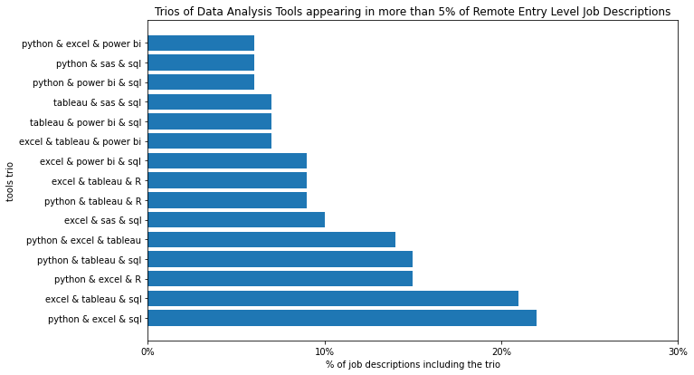

```python
plot_top_tools(sorted_tools_triple_percentages, 'trio')
```

## Trios of Tools: Percentage of Jobs Desriptions Mentioning the three Tools only or only two or one of them

Seems like having Excel, SQL & Python in your tool box may qualify you for about 36% of remote entry level Data Analyst jobs, while having Excel, SQL & SAS or Tableau for about 34%, and Excel, SQL & Power BI for about 30%.

> Learning Python, SAS or Tableau given you are proficient in Excel & SQL may increase the range of jobs you're qualified for by about 6-8%.

```python
# Checking the percentages of jobs descriptions completely covered by each tools trio

three_tools_descriptions = [desription for desription in jobs_descriptions if tools_per_description[desription] == 3]

tools_3_counts = {}

# Initializing the count dictionary of tools trios in jobs descriptions with a maximum of three tools
# with the sum of their counts in one & two tools descriptions
for tools_tuple in tools_triple:
    tools_3_counts[tools_tuple] = tools_2_counts[(tools_tuple[0], tools_tuple[1])]\
                                + (tools_2_counts[(tools_tuple[1], tools_tuple[2])]\
                                - tools_1_counts[tools_tuple[1]])\
                                + (tools_2_counts[(tools_tuple[0], tools_tuple[2])]\
                                - tools_1_counts[tools_tuple[0]]\
                                - tools_1_counts[tools_tuple[2]])
for tools_tuple in tools_double:
    tools_3_counts[(tools_tuple[0], tools_tuple[1], 'sql')] = tools_2_counts[(tools_tuple[0], tools_tuple[1])]\
                                                            + (tools_2_counts[(tools_tuple[1], 'sql')]\
                                                            - tools_1_counts[tools_tuple[1]])\
                                                            + (tools_2_counts[(tools_tuple[0], 'sql')]\
                                                            - tools_1_counts[tools_tuple[0]]\
                                                            - tools_1_counts['sql'])
    tools_3_counts[(tools_tuple[0], tools_tuple[1], 'R')] =  tools_2_counts[(tools_tuple[0], tools_tuple[1])]\
                                                            + (tools_2_counts[(tools_tuple[1], 'R')]\
                                                            - tools_1_counts[tools_tuple[1]])\
                                                            + (tools_2_counts[(tools_tuple[0], 'R')]\
                                                            - tools_1_counts[tools_tuple[0]]\
                                                            - tools_1_counts['R'])
tools_3_counts = fill_count_dictionary(tools_3_counts, tools_triple, tools_double, three_tools_descriptions)

sorted_tools_3_counts = sorted_dictionary(tools_3_counts)

sorted_tools_3_percentages = get_tool_percentages(sorted_tools_3_counts)
sorted_tools_3_percentages
```

```
{('python', 'excel', 'sql'): 0.36,
 ('excel', 'tableau', 'sql'): 0.34,
 ('excel', 'sas', 'sql'): 0.34,
 ('excel', 'power bi', 'sql'): 0.3,
 ('excel', 'spark', 'sql'): 0.28,
 ('excel', 'hadoop', 'sql'): 0.28,
 ('excel', 'looker', 'sql'): 0.28,
 ('excel', 'domo', 'sql'): 0.28,
 ('excel', 'airtable', 'sql'): 0.28,
 ('excel', 'elasticsearch', 'sql'): 0.28,
 ('excel', 'data factory', 'sql'): 0.28,
 ('excel', 'storm', 'sql'): 0.28,
 ('excel', 'qlikview', 'sql'): 0.28,
 ('excel', 'splunk', 'sql'): 0.28,
 ('excel', 'data studio', 'sql'): 0.28,
 ('excel', 'cognos', 'sql'): 0.28,
 ('excel', 'qlik', 'sql'): 0.28,
 ('excel', 'mysql', 'sql'): 0.28,
 ('excel', 'spss', 'sql'): 0.28,
 ('excel', 'talend', 'sql'): 0.28,
 ('excel', 'hubspot', 'sql'): 0.28,
 ('excel', 'orange', 'sql'): 0.28,
 ('excel', 'qualtrics', 'sql'): 0.28,
 ('excel', 'hive', 'sql'): 0.28,
 ('excel', 'pig', 'sql'): 0.28,
 ('python', 'excel', 'sas'): 0.23,
 ('python', 'excel', 'R'): 0.22,
 ('excel', 'power bi', 'sas'): 0.21,
 ('python', 'excel', 'tableau'): 0.2,
 ('excel', 'tableau', 'sas'): 0.2,
 ('excel', 'sas', 'R'): 0.2,
 ('python', 'excel', 'power bi'): 0.2,
 ('excel', 'looker', 'sas'): 0.2,
 ('excel', 'spss', 'sas'): 0.2,
 ('excel', 'sas', 'airtable'): 0.2,
 ('excel', 'sas', 'elasticsearch'): 0.2,
 ('python', 'excel', 'spark'): 0.19,
 ('python', 'excel', 'looker'): 0.19,
 ('python', 'excel', 'airtable'): 0.19,
 ('python', 'excel', 'elasticsearch'): 0.19,
```

[output cut: 946 more lines]

```
 ('hubspot', 'sas', 'airtable'): 0.02,
 ('orange', 'sas', 'airtable'): 0.02,
 ('qualtrics', 'sas', 'airtable'): 0.02,
 ('sas', 'airtable', 'elasticsearch'): 0.02,
 ('sas', 'airtable', 'hive'): 0.02,
 ('sas', 'airtable', 'data factory'): 0.02,
 ('sas', 'airtable', 'pig'): 0.02,
 ('tableau', 'sas', 'R'): 0.02,
 ('sas', 'airtable', 'R'): 0.02,
 ('spark', 'hadoop', 'sas'): 0.01,
 ('spark', 'storm', 'sas'): 0.01,
 ('spark', 'qlikview', 'sas'): 0.01,
 ('spark', 'splunk', 'sas'): 0.01,
 ('spark', 'power bi', 'sas'): 0.01,
 ...}
```

## Part V - Quadruples of Tools Analysis

```python
tools_quadruple = itertools.combinations(tools, 4) # tools quadruples
```

```python
tools_quadruple_counts = initialize_count_dictionary(tools_quadruple, tools_triple)
tools_quadruple_counts
```

[output not shown]

[output cut: 946 more lines]

[output not shown]

```python
tools_quadruple_counts = fill_count_dictionary(tools_quadruple_counts, tools_quadruple, tools_triple, jobs_descriptions)

sorted_tools_quadruple_counts = sorted_dictionary(tools_quadruple_counts)
sorted_tools_quadruple_counts
```

```
{('python', 'excel', 'tableau', 'sql'): 26,
 ('python', 'excel', 'tableau', 'R'): 17,
 ('excel', 'tableau', 'power bi', 'sql'): 12,
 ('python', 'excel', 'power bi', 'sql'): 11,
 ('python', 'tableau', 'power bi', 'sql'): 11,
 ('excel', 'tableau', 'sas', 'sql'): 11,
 ('python', 'excel', 'power bi', 'R'): 10,
 ('python', 'excel', 'sas', 'sql'): 9,
 ('python', 'tableau', 'power bi', 'R'): 9,
 ('python', 'excel', 'sas', 'R'): 8,
 ('excel', 'tableau', 'power bi', 'R'): 8,
 ('excel', 'power bi', 'sas', 'sql'): 8,
 ('tableau', 'power bi', 'sas', 'sql'): 8,
 ('python', 'tableau', 'sas', 'sql'): 7,
 ('python', 'excel', 'looker', 'sql'): 6,
 ('python', 'tableau', 'sas', 'R'): 6,
 ('python', 'power bi', 'sas', 'sql'): 6,
 ('excel', 'tableau', 'sas', 'R'): 6,
 ('tableau', 'power bi', 'sas', 'R'): 6,
 ('python', 'excel', 'looker', 'R'): 5,
 ('python', 'excel', 'mysql', 'sql'): 5,
 ('python', 'tableau', 'looker', 'sql'): 5,
 ('python', 'tableau', 'mysql', 'sql'): 5,
 ('python', 'power bi', 'sas', 'R'): 5,
 ('excel', 'tableau', 'mysql', 'sql'): 5,
 ('excel', 'power bi', 'sas', 'R'): 5,
 ('python', 'excel', 'spss', 'sql'): 4,
 ('python', 'excel', 'spss', 'R'): 4,
 ('python', 'hadoop', 'tableau', 'sql'): 4,
 ('python', 'tableau', 'looker', 'R'): 4,
 ('python', 'tableau', 'mysql', 'R'): 4,
 ('python', 'tableau', 'spss', 'R'): 4,
 ('python', 'spss', 'sas', 'R'): 4,
 ('excel', 'tableau', 'data studio', 'sql'): 4,
 ('excel', 'tableau', 'looker', 'sql'): 4,
 ('python', 'excel', 'hadoop', 'sql'): 3,
 ('python', 'excel', 'data studio', 'sql'): 3,
 ('python', 'excel', 'mysql', 'R'): 3,
 ('python', 'tableau', 'data studio', 'R'): 3,
 ('python', 'tableau', 'spss', 'sql'): 3,
```

[output cut: 946 more lines]

```
 ('python', 'hadoop', 'qlik', 'data factory'): 0,
 ('python', 'hadoop', 'qlik', 'pig'): 0,
 ('python', 'hadoop', 'domo', 'mysql'): 0,
 ('python', 'hadoop', 'domo', 'spss'): 0,
 ('python', 'hadoop', 'domo', 'talend'): 0,
 ('python', 'hadoop', 'domo', 'hubspot'): 0,
 ('python', 'hadoop', 'domo', 'orange'): 0,
 ('python', 'hadoop', 'domo', 'qualtrics'): 0,
 ('python', 'hadoop', 'domo', 'sas'): 0,
 ('python', 'hadoop', 'domo', 'airtable'): 0,
 ('python', 'hadoop', 'domo', 'elasticsearch'): 0,
 ('python', 'hadoop', 'domo', 'hive'): 0,
 ('python', 'hadoop', 'domo', 'data factory'): 0,
 ('python', 'hadoop', 'domo', 'pig'): 0,
 ...}
```

```python
sorted_tools_quadruple_percentages = get_tool_percentages(sorted_tools_quadruple_counts)
sorted_tools_quadruple_percentages
```

```
{('python', 'excel', 'tableau', 'sql'): 0.11,
 ('python', 'excel', 'tableau', 'R'): 0.07,
 ('excel', 'tableau', 'power bi', 'sql'): 0.05,
 ('python', 'excel', 'power bi', 'sql'): 0.05,
 ('python', 'tableau', 'power bi', 'sql'): 0.05,
 ('excel', 'tableau', 'sas', 'sql'): 0.05,
 ('python', 'excel', 'power bi', 'R'): 0.04,
 ('python', 'excel', 'sas', 'sql'): 0.04,
 ('python', 'tableau', 'power bi', 'R'): 0.04,
 ('python', 'excel', 'sas', 'R'): 0.03,
 ('excel', 'tableau', 'power bi', 'R'): 0.03,
 ('excel', 'power bi', 'sas', 'sql'): 0.03,
 ('tableau', 'power bi', 'sas', 'sql'): 0.03,
 ('python', 'tableau', 'sas', 'sql'): 0.03,
 ('python', 'excel', 'looker', 'sql'): 0.03,
 ('python', 'tableau', 'sas', 'R'): 0.03,
 ('python', 'power bi', 'sas', 'sql'): 0.03,
 ('excel', 'tableau', 'sas', 'R'): 0.03,
 ('tableau', 'power bi', 'sas', 'R'): 0.03,
 ('python', 'excel', 'looker', 'R'): 0.02,
 ('python', 'excel', 'mysql', 'sql'): 0.02,
 ('python', 'tableau', 'looker', 'sql'): 0.02,
 ('python', 'tableau', 'mysql', 'sql'): 0.02,
 ('python', 'power bi', 'sas', 'R'): 0.02,
 ('excel', 'tableau', 'mysql', 'sql'): 0.02,
 ('excel', 'power bi', 'sas', 'R'): 0.02,
 ('python', 'excel', 'spss', 'sql'): 0.02,
 ('python', 'excel', 'spss', 'R'): 0.02,
 ('python', 'hadoop', 'tableau', 'sql'): 0.02,
 ('python', 'tableau', 'looker', 'R'): 0.02,
 ('python', 'tableau', 'mysql', 'R'): 0.02,
 ('python', 'tableau', 'spss', 'R'): 0.02,
 ('python', 'spss', 'sas', 'R'): 0.02,
 ('excel', 'tableau', 'data studio', 'sql'): 0.02,
 ('excel', 'tableau', 'looker', 'sql'): 0.02,
 ('python', 'excel', 'hadoop', 'sql'): 0.01,
 ('python', 'excel', 'data studio', 'sql'): 0.01,
 ('python', 'excel', 'mysql', 'R'): 0.01,
 ('python', 'tableau', 'data studio', 'R'): 0.01,
 ('python', 'tableau', 'spss', 'sql'): 0.01,
```

[output cut: 946 more lines]

```
 ('python', 'hadoop', 'qlik', 'data factory'): 0.0,
 ('python', 'hadoop', 'qlik', 'pig'): 0.0,
 ('python', 'hadoop', 'domo', 'mysql'): 0.0,
 ('python', 'hadoop', 'domo', 'spss'): 0.0,
 ('python', 'hadoop', 'domo', 'talend'): 0.0,
 ('python', 'hadoop', 'domo', 'hubspot'): 0.0,
 ('python', 'hadoop', 'domo', 'orange'): 0.0,
 ('python', 'hadoop', 'domo', 'qualtrics'): 0.0,
 ('python', 'hadoop', 'domo', 'sas'): 0.0,
 ('python', 'hadoop', 'domo', 'airtable'): 0.0,
 ('python', 'hadoop', 'domo', 'elasticsearch'): 0.0,
 ('python', 'hadoop', 'domo', 'hive'): 0.0,
 ('python', 'hadoop', 'domo', 'data factory'): 0.0,
 ('python', 'hadoop', 'domo', 'pig'): 0.0,
 ...}
```

## Most Frequently Mentioned Quadruples of Tools

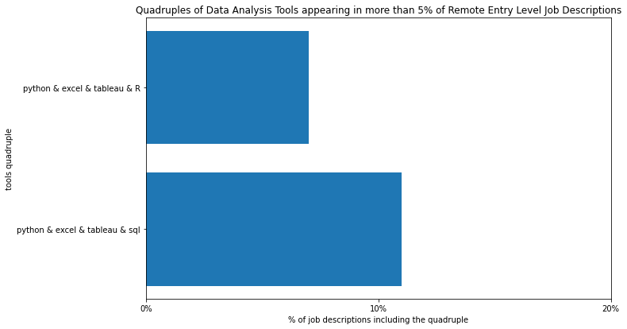

```python
plot_top_tools(sorted_tools_quadruple_percentages, 'quadruple')
```

## Quadruples of Tools: Percentage of Jobs Desriptions Mentioning the four Tools only or only three, two or one of them

Seems like having Excel, SQL, Tableau & SAS in your tool box may qualify you for more than half of the remote entry level Data Analyst jobs (about 51%), while having Excel, SQL, Tableau & Python or SAS & Power BI for about 48%, Excel, SQL, Python & SAS for about 47%, and Excel, SQL, Tableau & Power BI for about 46%.

> Learning Tableau given you are proficient in Excel, SQL & Python may increase the range of jobs you're qualified for by ~12%, while learning Tableau or SAS given you are proficient in Excel, SQL & one of the two my increase it by ~17%.

```python
# Checking the percentages of jobs descriptions completely covered by each tools quadruple

four_tools_descriptions = [desription for desription in jobs_descriptions if tools_per_description[desription] == 4]

tools_4_counts = {}

# Initializing the count dictionary of tools quadruples in jobs descriptions with a maximum of four tools
# with the sum of their counts in one, two & three tools descriptions
for tools_tuple in tools_quadruple:
    tools_4_counts[tools_tuple] = tools_3_counts[(tools_tuple[0], tools_tuple[1], tools_tuple[2])]\
                                + (tools_3_counts[(tools_tuple[0], tools_tuple[1], tools_tuple[3])]\
                                - tools_2_counts[(tools_tuple[0], tools_tuple[1])])\
                                + (tools_3_counts[(tools_tuple[0], tools_tuple[2], tools_tuple[3])]\
                                - tools_2_counts[(tools_tuple[0], tools_tuple[2])]\
                                - tools_1_counts[tools_tuple[3]])\
                                + (tools_3_counts[(tools_tuple[1], tools_tuple[2], tools_tuple[3])]\
                                - tools_2_counts[(tools_tuple[1], tools_tuple[3])]\
                                + tools_1_counts[tools_tuple[3]]\
                                - tools_2_counts[(tools_tuple[2], tools_tuple[3])])
for tools_tuple in tools_triple:
    tools_4_counts[(tools_tuple[0], tools_tuple[1], tools_tuple[2], 'sql')]\
        = tools_3_counts[(tools_tuple[0], tools_tuple[1], tools_tuple[2])]\
            + (tools_3_counts[(tools_tuple[0], tools_tuple[1], 'sql')]\
            - tools_2_counts[(tools_tuple[0], tools_tuple[1])])\
            + (tools_3_counts[(tools_tuple[0], tools_tuple[2], 'sql')]\
            - tools_2_counts[(tools_tuple[0], tools_tuple[2])]\
            - tools_1_counts['sql'])\
            + (tools_3_counts[(tools_tuple[1], tools_tuple[2], 'sql')]\
            - tools_2_counts[(tools_tuple[1], 'sql')]\
            + tools_1_counts['sql']\
            - tools_2_counts[(tools_tuple[2], 'sql')])
    tools_4_counts[(tools_tuple[0], tools_tuple[1], tools_tuple[2], 'R')]\
        = tools_3_counts[(tools_tuple[0], tools_tuple[1], tools_tuple[2])]\
            + (tools_3_counts[(tools_tuple[0], tools_tuple[1], 'R')]\
            - tools_2_counts[(tools_tuple[0], tools_tuple[1])])\
            + (tools_3_counts[(tools_tuple[0], tools_tuple[2], 'R')]\
            - tools_2_counts[(tools_tuple[0], tools_tuple[2])]\
            - tools_1_counts['R'])\
            + (tools_3_counts[(tools_tuple[1], tools_tuple[2], 'R')]\
            - tools_2_counts[(tools_tuple[1], 'R')]\
            + tools_1_counts['R']\
            - tools_2_counts[(tools_tuple[2], 'R')])

tools_4_counts = fill_count_dictionary(tools_4_counts, tools_quadruple, tools_triple, four_tools_descriptions)

sorted_tools_4_counts = sorted_dictionary(tools_4_counts)

sorted_tools_4_percentages = get_tool_percentages(sorted_tools_4_counts)
sorted_tools_4_percentages
```

```
{('excel', 'tableau', 'sas', 'sql'): 0.51,
 ('python', 'excel', 'tableau', 'sql'): 0.48,
 ('excel', 'power bi', 'sas', 'sql'): 0.48,
 ('python', 'excel', 'sas', 'sql'): 0.47,
 ('excel', 'tableau', 'power bi', 'sql'): 0.46,
 ('excel', 'tableau', 'looker', 'sql'): 0.45,
 ('excel', 'tableau', 'domo', 'sql'): 0.45,
 ('excel', 'spark', 'tableau', 'sql'): 0.44,
 ('excel', 'hadoop', 'tableau', 'sql'): 0.44,
 ('excel', 'tableau', 'airtable', 'sql'): 0.44,
 ('excel', 'tableau', 'elasticsearch', 'sql'): 0.44,
 ('excel', 'tableau', 'data factory', 'sql'): 0.44,
 ('excel', 'spark', 'sas', 'sql'): 0.44,
 ('excel', 'hadoop', 'sas', 'sql'): 0.44,
 ('excel', 'storm', 'tableau', 'sql'): 0.44,
 ('excel', 'tableau', 'qlikview', 'sql'): 0.44,
 ('excel', 'tableau', 'splunk', 'sql'): 0.44,
 ('excel', 'tableau', 'data studio', 'sql'): 0.44,
 ('excel', 'tableau', 'cognos', 'sql'): 0.44,
 ('excel', 'tableau', 'qlik', 'sql'): 0.44,
 ('excel', 'tableau', 'mysql', 'sql'): 0.44,
 ('excel', 'tableau', 'spss', 'sql'): 0.44,
 ('excel', 'tableau', 'talend', 'sql'): 0.44,
 ('excel', 'tableau', 'hubspot', 'sql'): 0.44,
 ('excel', 'tableau', 'orange', 'sql'): 0.44,
 ('excel', 'tableau', 'qualtrics', 'sql'): 0.44,
 ('excel', 'tableau', 'hive', 'sql'): 0.44,
 ('excel', 'tableau', 'pig', 'sql'): 0.44,
 ('excel', 'cognos', 'sas', 'sql'): 0.44,
 ('excel', 'looker', 'sas', 'sql'): 0.44,
 ('excel', 'domo', 'sas', 'sql'): 0.44,
 ('excel', 'spss', 'sas', 'sql'): 0.44,
 ('excel', 'qualtrics', 'sas', 'sql'): 0.44,
 ('excel', 'sas', 'airtable', 'sql'): 0.44,
 ('excel', 'sas', 'elasticsearch', 'sql'): 0.44,
 ('excel', 'sas', 'data factory', 'sql'): 0.44,
 ('excel', 'storm', 'sas', 'sql'): 0.43,
 ('excel', 'qlikview', 'sas', 'sql'): 0.43,
 ('excel', 'splunk', 'sas', 'sql'): 0.43,
 ('excel', 'data studio', 'sas', 'sql'): 0.43,
```

[output cut: 946 more lines]

```
 ('python', 'airtable', 'hive', 'R'): 0.05,
 ('python', 'airtable', 'data factory', 'R'): 0.05,
 ('python', 'airtable', 'pig', 'R'): 0.05,
 ('spark', 'hadoop', 'sas', 'sql'): 0.05,
 ('spark', 'power bi', 'sas', 'sql'): 0.05,
 ('spark', 'cognos', 'sas', 'sql'): 0.05,
 ('spark', 'sas', 'airtable', 'sql'): 0.05,
 ('hadoop', 'storm', 'tableau', 'sql'): 0.05,
 ('hadoop', 'tableau', 'qlikview', 'sql'): 0.05,
 ('hadoop', 'tableau', 'splunk', 'sql'): 0.05,
 ('hadoop', 'tableau', 'power bi', 'sql'): 0.05,
 ('hadoop', 'tableau', 'data studio', 'sql'): 0.05,
 ('hadoop', 'tableau', 'cognos', 'sql'): 0.05,
 ('hadoop', 'tableau', 'looker', 'sql'): 0.05,
 ...}
```

## Part V - Key Takeaways

### Finally, we plotted the best concluded learning paths for qualifying for most Data Analysis remote entry level jobs based on the number of tools you are willing to learn

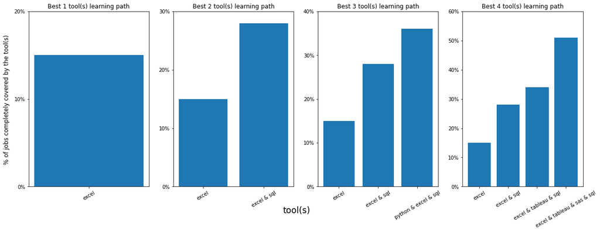

```python
# Most important tools to learn -sorted by importance- for qualifying
# for most Data Analysis remote entry level jobs

# Best 1 tool learning path
plot_1_dict = {list(sorted_tools_1_percentages.keys())[0]: list(sorted_tools_1_percentages.values())[0]}
# Best 2 tools learning path
plot_2_dict = {list(sorted_tools_1_percentages.keys())[0]: list(sorted_tools_1_percentages.values())[0], \
               list(sorted_tools_2_percentages.keys())[0]: list(sorted_tools_2_percentages.values())[0]}
# Best 3 tools learning path
plot_3_dict = {list(sorted_tools_1_percentages.keys())[0]: list(sorted_tools_1_percentages.values())[0], \
               list(sorted_tools_2_percentages.keys())[0]: list(sorted_tools_2_percentages.values())[0], \
               list(sorted_tools_3_percentages.keys())[0]: list(sorted_tools_3_percentages.values())[0]}
# Best 4 tools learning path
plot_4_dict = {list(sorted_tools_1_percentages.keys())[0]: list(sorted_tools_1_percentages.values())[0], \
               list(sorted_tools_2_percentages.keys())[0]: list(sorted_tools_2_percentages.values())[0], \
               list(sorted_tools_3_percentages.keys())[1]: list(sorted_tools_3_percentages.values())[1], \
               list(sorted_tools_4_percentages.keys())[0]: list(sorted_tools_4_percentages.values())[0]}

plot_dicts = [plot_1_dict, plot_2_dict, plot_3_dict, plot_4_dict]

fig, axes = plt.subplots(1, 4)
fig.set_size_inches(20, 6.5)

i = 0
for ax in axes:
    if i == 0:
        ax.bar(plot_dicts[0].keys(), plot_dicts[0].values())
    else:
        ax.bar([list(plot_dicts[i].keys())[0]] + [' & '.join(set) for set in list(plot_dicts[i].keys())[1:]], plot_dicts[i].values())

    for tick in ax.get_xticklabels():
        tick.set_rotation(30)

    y_range = range(0, int(max(list(plot_dicts[i].values()))*100)+10, 10)
    ax.set_yticks([i/100 for i in y_range])
    ax.set_yticklabels(str(i) + '%' for i in range(0, int(max(list(plot_dicts[i].values()))*100)+10, 10))
    ax.title.set_text('Best ' + str(i+1) + ' tool(s) learning path')

    i += 1

fig.text(0.5, 0.01, 'tool(s)', ha='center', size='xx-large')
fig.text(0.09, 0.5, '% of jobs completely covered by the tool(s)', va='center', rotation='vertical', size='large');
```